# lab

**Convex and Distributed Optimization Lab**  
**MSIAM — Université Grenoble Alpes — 2018/2019**  
**Lecturers: Jérôme Malick, Yassine Laguel, Sélim Chraibi**

**Author(s): Xhenis COBA, Nabil MENAI, Predrag PILIPOVIC**

```python
# Automatic reload of local libraries
%load_ext autoreload
%autoreload 2
%reload_ext autoreload
%matplotlib inline
```

> **I. Introduction**  
> **II. The optimization problem**  
> **III. Implementing the solvers**  
> GD (Gradient descent))  
> SGD (Stochastic Gradient Descent))  
> SAGA (Stochastic Average Gradient "Amélioré"))  
> SVRG (Stochastic Variance Reduced Gradient))  
> Comparison  
> **IV. Regularization**  
> **V. Further development**  
> **References**

In this lab, you will implement optimization algorithms that you've studied in class and use them to fit a logistic regression classification model.

You will be implementing a simplified version of [`sklearn.linear_model.LogisticRegression`](https://scikit-learn.org/stable/modules/generated/sklearn.linear_model.LogisticRegression.html).

Part of the work has already been done for you (see the `\lib` folder), so you'll only have to implement the `##### TODO (i) #####` sections of the code. Whenever you complete such a section, we ask you to **copy it in this notebook**. We want you to **only send us a pdf or html export of this notebook** so we won't be able to see your work if it's not in this notebook.

Report in groups of 1 to 3 students.  
**Due date:** Monday, January 6, 2019 (before midnight).  
**Send to:** cdo.grenoble@gmail.com

# I. Introduction

We consider the [Student Performance](http://archive.ics.uci.edu/ml/datasets/Student+Performance) dataset. This dataset contains student demographic, social, school-related features, how many classes they've missed, etc.

The goal we give ourselves is to predict whether a student will pass (final grade > 12).

We denote $A \in \mathcal{M}_{n,d}(\mathbb{R})$ the feature matrix, containing $n$ samples with $d$ features, and $b \in \{-1,1\}^n$ the label vector where $-1$ encodes `fail` and $1$ encodes `pass`.

The data has already been preprocessed (yay less work for you 🎉). You can check `\lib\datasets.py` if you're curious, otherwise, you can just use the following to load your dataset:

```python
from lib.datasets import load_student_data

A_train, A_test, b_train, b_test = load_student_data('data/student-mat.csv', split=0.25)
```

As mentioned previously, you're going to implement a simplified version of [`sklearn.linear_model.LogisticRegression`](https://scikit-learn.org/stable/modules/generated/sklearn.linear_model.LogisticRegression.html). So let's first see what the finished product should look like.

**Question:**

- Import [sklearn.linear_model.LogisticRegression](https://scikit-learn.org/stable/modules/generated/sklearn.linear_model.LogisticRegression.html) .
- Create an instance of sklearn's logistic regression classifiers with SAGA as its solver.
- Fit the classifier on the training data and compute the score of the fitted model on the test set.

```python
from sklearn.linear_model import LogisticRegression
from sklearn.metrics import confusion_matrix
import matplotlib.pyplot as plt
import seaborn as sns

clf = LogisticRegression(solver = 'saga').fit(A_train, b_train)
b_predicted = clf.predict(A_test)
l = (b_test == b_predicted)
clf.score(A_test, b_test)
```

```
0.9696969696969697
```

We trained our Logistic regression model with SAGA solver, and used it to predict labels of test data. After that we compared test labels with true lables, and we got the score by computing the percentage of how may correct predictiona we had. The implemented score method did the same thing. We can also take a look at the confusion matrix below to see in more detail the accuracy of the model.

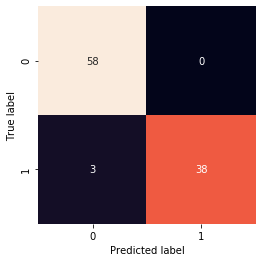

```python
mat = confusion_matrix(b_test, b_predicted)
sns.heatmap(mat, square = True, annot = True, cbar = False)
plt.ylabel('True label')
plt.xlabel('Predicted label')
```

# II. The optimization problem

[figure not shown]

)Logistic regression consists in finding the parameter $x \in \mathbb{R}^d$ that best fits: $$ b_i = \begin{cases} \phantom{-}1 \ \textrm{ if }\ \langle a_{i}, x\rangle \ge 0 \\ -1 \ \textrm{ if }\ \langle a_{i}, x\rangle < 0 \end{cases} $$ for all the samples $i$ of the training set (where $a_i$ is the $i^{th}$ column of $A$ and $b_i$ the $i^{th}$ element of $b$). To measure this fit, logistic regression chooses the following loss:

$$ \textrm{LogisticLoss}(b_i, \left\langle a_{i}, x\right\rangle ) = \log \left(1+\exp \left(-b_{i}\left\langle a_{i}, x\right\rangle\right)\right) $$

The corresponding optimization problem we will consider is the following:

Minimization of the empirical risk $f$ of the $L_2$-regularized logistic regression model, on the dataset $(A_{\textrm{train}},b_{\textrm{train}})$: $$ \begin{aligned} \textrm{min}_{x\in \mathbb{R}^d} \ f(x) \ &= \ \textrm{min}_{x\in \mathbb{R}^d} \ \frac{1}{n_{\textrm{train}}} \sum_{i=1}^{n_{\textrm{train}}} f_i(x) \\ &= \ \textrm{min}_{x\in \mathbb{R}^d}\frac{1}{n_{\textrm{train}}} \sum_{i=1}^{n_{\textrm{train}}} \textrm{LogisticLoss}(b_i, \left\langle a_{i}, x\right\rangle ) + \frac{l_2}{2}\|x\|^{2}_2, \end{aligned} $$ where $l_2 \ge 0$ is the $L_2$ regularization coefficient.

To simplify the notation, we'll stop indexing $A$, $b$ and $n$ with "$\textrm{train}$" in the following.

**Question:** $f$ is $\mu$-strongly convex.

- Give a lower bound on $\mu$.
- Complete **TODO (1)** in **\lib\linear_model.py**.

> **Answer:** Let us recall the definition of $\mu$-strongly convex.

> $\mathbf{Definition.}$ A function $f$ is $\mu$-strongly convex if

> $$f(x) − \frac{\mu}{2}||x||^2$$

> is convex, for all $x$, where $\mu > 0$.

> $\mathbf{Proposition.}$ A differentiable function $f$ is $\mu$-strongly convex if and only if

> $$f(y) \geq f(x) + \nabla f(x)^T (y-x) + \frac{\mu}{2}||y-x||^2,$$

> for all $x,y$.

> *Proof.* Let us denote $g(x)= f(x)-\frac{\mu}{2}||x||^2$. This proposition follows from the first-order condition for convexity of $g(x)$, i.e. $g(x)$ is convex if and only if

> $$g(y) \geq g(x) + \nabla g(x)^T (y-x),$$ for all $x,y$.
> - $(\Leftarrow)$ We want to prove that $f$ is a strongly convex function with constant $\mu > 0$. From the assumption we have \begin{align*} g(y) - g(x) &= f(y)- f(x) - \frac{\mu}{2}\left(||y||^2 - ||x||^2\right)\\ &\geq \nabla f(y)^T (y-x) + \frac{\mu}{2}||y-x||^2 - \frac{\mu}{2}\left(||y||^2 - ||x||^2\right)\\ &= \nabla f(y)^T (y-x) + \frac{\mu}{2}||x||^2 + \frac{\mu}{2}||y||^2 - \mu y^T x - \frac{\mu}{2} \left(||x||^2 - ||y||^2\right)\\ &=\nabla f(y)^T (y-x) - \mu y^T x + \mu ||y||^2\\ &= \left(\nabla f(y)-\mu y\right)^T (y-x) \\ &= \nabla g(y)^T (y-x), \end{align*} and thus $g$ is convex, i.e. $f$ is $\mu$-strongly convex.
> - $(\Rightarrow)$ Now suppose there exists $\mu > 0$ such that $g$ is convex. Then \begin{align*} f(y) - f(x) &= g(y)- g(x) + \frac{\mu}{2}\left(||y||^2 - ||x||^2\right)\\ &\geq \nabla g(y)^T(y-x) + \frac{\mu}{2}\left(||y||^2 - ||x||^2\right). \end{align*} Using the same calculation, we can show that this last line is equal to $$\nabla f(y)^T(y-x)+\frac{\mu}{2}||y-x||^2,$$ and thus, $f$ satisfies the assumption from proposition.

> $$\hspace{15cm} \blacksquare$$

> Now, let us go back to the problem. Because the logistic loss function is convex, the function $f$ is also $l_2$-strongly convex. Having in mind that $l_2$ is fixed constant, we want to see what $\mu$ can be in terms of $l_2$. From $l_2$-strongly convexity we have

> $$f(y) \geq f(x) + \nabla f(x)^T (y-x) + \frac{l_2}{2}||y-x||^2,$$

> and we want to find all $\mu$ such that

> $$f(y) \geq f(x) + \nabla f(x)^T (y-x) + \frac{\mu}{2}||y-x||^2.$$

> For every $\mu \geq l_2$, we could conlcude from $\mu$-strongly convexity that $f$ is $l_2$-strongly convex.

**Question:** Denote $\lambda_{\max}$ the largest eigenvalue of the real symmetric matrix $AA^T$.

- Prove that $\lambda_{\max}\left(\nabla^2 f_i\right) \le \lambda_{\max}\left(\frac{a_i a_i^T}{4} + l_2 I_n\right)$
- Prove that $\lambda_{\max}(a_i a_i^T) \le \|a_i\|^2_2$

> **Answer:** First of all, we need to compute Hessian of $f_i$. We can see from the above that $$f_i(x) = \log(1+\exp(-b_i\langle a_i, x\rangle)) + \frac{l_2}{2}||x||^2.$$ In order to compute Hessian, firstly we need to find $\frac{\partial f_i}{\partial x_j}$, for all $j=1,2,...,n$. Using fact that $\langle a_i, x\rangle = \sum\limits_{j=1}^n a_{ij}x_j$, and $||x||^2 = \sum\limits_{j=1}^n x_j^2$, we have

> \begin{align*} \frac{\partial f_i}{\partial x_j} &= \frac{1}{1+\exp(-b_i\langle a_i, x\rangle)}\cdot\exp(-b_i\langle a_i,x\rangle)\cdot(-b_ia_{ij}) + l_2x_j\\ &= - \frac{a_{ij}b_i}{1+\exp(b_i\langle a_i, x\rangle)} + l_2 x_j. \end{align*}

> From the previous line we have Jacobian, which we do not need now, but it will be needed later. We just need to put all the $\frac{\partial f_i}{\partial x_j}$ into vector through all $j=1,2,...,n$ and we will have

> $$\nabla f_i = - \frac{a_{i}b_i}{1+\exp(b_i\langle a_i, x\rangle)} + l_2 x.$$

> To find Hessian, now we need to find $\frac{\partial^2 f_i}{\partial x_j\partial x_k}$, for all $j,k=1,2,...,n$. We have

> \begin{align*} \frac{\partial^2 f_i}{\partial x_j\partial x_k} &= \frac{a_{ij}b_i}{(1+\exp(b_i\langle a_i, x\rangle))^2}\cdot \exp(b_i\langle a_i, x\rangle)\cdot b_ia_{ik} + l_2 \delta_k^j\\ &= b_i^2\cdot \frac{1}{1+\exp(b_i\langle a_i, x\rangle)}\cdot\frac{1}{1+\exp(-b_i\langle a_i, x\rangle)}\cdot a_{ij}a_{ik} + l_2\delta_k^j\\ &= \sigma(b_i\langle a_i, x\rangle)\sigma(-b_i\langle a_i, x\rangle) \cdot a_{ij}a_{ik} + l_2\delta_k^j, \end{align*}

> where $\delta_k^j$ is Kronecker delta function. In the last line we used that $b_i \in \{-1, 1\}$, so it must be $b_i^2 = 1$. Also, we denoted sigmoid function

> $$\sigma(x) = \frac{1}{1+\exp(-x)}.$$

> It is good now to notice the property of sigmoid function, i.e.

> $$\sigma(x) = \frac{\exp(x)}{1+\exp(x)} = 1 - \frac{1}{1+\exp(x)} = 1 - \sigma(-x).$$

> In order to find Hessian we need to put $\frac{\partial^2 f_i}{\partial x_j\partial x_k}$ through all $j, k = 1,2,...,n$, so we will have

> \begin{align*} \nabla^2 f_i &= \sigma(b_i\langle a_i, x\rangle)\sigma(-b_i\langle a_i, x\rangle) \begin{bmatrix} a_{i1}^2 & a_{i1}a_{i2} & \dots & a_{i1}a_{in}\\ a_{i2}a_{i1} & a_{i2}^2 & \dots & a_{i2}a_{in}\\ \vdots & \vdots & \ddots & \vdots\\ a_{in}a_{i1} & a_{in}a_{i2} & ... & a_{in}^2 \end{bmatrix} + l_2 I_n\\ &= \sigma(b_i\langle a_i, x\rangle)\sigma(-b_i\langle a_i, x\rangle) a_ia_i^T + l_2 I_n. \end{align*}

> Let us now show that $\sigma(b_i\langle a_i, x\rangle)\sigma(-b_i\langle a_i, x\rangle) \leq \frac{1}{4}$. This is because of the property of sigmoid function, we now

> \begin{align*} \sigma(x)\sigma(-x) = \sigma(x)(1-\sigma(x)) = -\left(\sigma^2(x) - \sigma(x) + \frac{1}{4}\right) +\frac{1}{4} = \underbrace{-\left(\sigma(x)-\frac{1}{2}\right)^2}_{\leq 0} + \frac{1}{4} \leq \frac{1}{4}, \end{align*}

> for all $x\in \mathbb{R}$. It is now time to prove that

> $$\lambda_{\max}\left(\nabla^2 f_i\right) \leq \lambda_{\max}\left(\frac{a_i a_i^T}{4} + l_2 I_n\right).$$

> For this reason we need to introduce symmetric matrix inequalty.

> $\mathbf{Definition.}$ Let $A$ and $B$ symmetric matrices of dimension $n\times n$. We say that $A-B$ is negative semi definite, and we write $A \preceq B$, if for all vecotrs $v \in \mathbb{R}^n$ we have

> $$v^T A v \leq v^T B v.$$

> Let us show that this definition is equivalent to the fact that all eigenvalues of $B$ are at least as big as all eigenvalues of $A$. Actually, we do not need to prove this, just one part of it.

> $\mathbf{Theorem.}$ If $A \preceq B$, then $\lambda_{\max}(A)\leq \lambda_{\max}(B)$

> *Proof.* From the asummption we have

> $$v^T A v \leq v^T B v,$$

> for all vecotrs $v \in \mathbb{R}^n$. Becasue $B$ is symmetric we know we can decomponise it as $Q\Lambda Q^T$, such that the matrix $Q$ is a real orthogonal matrix, (the columns of which are eigenvectors of $B$), and $\Lambda$ is real and diagonal (having the eigenvalues of $B$ on the diagonal). On the right hand side we have

> \begin{align*} v^T B v &= v^T Q \Lambda Q^T v = \left(Q^T v\right)^T \Lambda \left(Q^T v\right) = \sum_{i=1}^n \lambda_i(B) \left(q_i^T v\right)^2\\ &\leqslant \lambda_{\max}(B) \sum_{i=1}^n \left(q_i^T v\right)^2 = \lambda_{\max}(B) \left|\left| Q^T v\right|\right|^2 = \lambda_{\max}(B) ||v||^2. \end{align*}

> In the last line we used the fact that $Q$ is orthogonal, or $Q^TQ = I_n$, so we have

> $$\left|\left|Q^Tv\right|\right|^2 = \left\langle Q^Tv, Q^Tv\right\rangle = \left\langle QQ^T v, v\right\rangle = \left\langle v,v \right\rangle = ||v||^2.$$ So, we proved that for all $v\in \mathbb{R}^n$ it is

> $$v^T A v \leq v^T B v \leq \lambda_{\max}(B) ||v||^2.$$

> Now, we can fix $v$ to be eigenvector of $A$, i.e. let $v = w$, where $A w = \lambda_w(A) w$, so we have

> $$ \lambda_{\max}(B) ||w||^2 \geq w^T A w = w^T \lambda_w(A) w = \lambda_w(A) ||w||^2,$$

> which means that $\lambda_w(A) \leq \lambda_{\max}(B)$, for all eigenvectors $w$ of $A$. Finally, we can conclude that

> $$\lambda_{\max}(A)\leq \lambda_{\max}(B). $$ $$\hspace{15cm} \blacksquare$$

> We can come back to our problem now. If we put $A = \nabla^2 f_i$ and $B = \frac{a_i a_i^T}{4} + l_2 I_n$, it will be $A \preceq B$. We saw that

> $$\nabla^2 f_i = \underbrace{\sigma(b_i\langle a_i, x\rangle)\sigma(-b_i\langle a_i, x\rangle)}_{c} a_ia_i^T + l_2 I_n,$$

> where $c \leq \frac{1}{4}$. So, for all $v\in \mathbb{R}^n$, we have

> $$c v^T a_ia_i^T v \leq \frac{1}{4} v^T a_ia_i^T v,$$

> from where we can conclude

> $$v^T\left(c a_ia_i^T + l_2 I_n\right)v \leq v^T \left(\frac{1}{4}a_ia_i^T + l_2I_n\right) v.$$

> And finally, after applying the previous theorem, we can conclude that

> $$\lambda_{\max}\left(\nabla^2 f_i\right) \leq \lambda_{\max}\left(\frac{a_i a_i^T}{4} + l_2 I_n\right).$$

> For the second part we will use the fact that $a_i a_i^T $ is symmetric positive semi definite, which means that all eigenvalues of $a_ia_i^T$ are nonegative. We want to prove

> $$\lambda_{\max}(a_ia_i^T) \leq ||a_i||_2^2.$$

> We can see that right hand side is a trace of $a_ia_i^T$, which means that the previous line is equivalent to

> $$\lambda_{\max}(a_ia_i^T) \leq ||a_i||_2^2 = \text{tr}(a_ia_i^T) = \sum_{k=1}^n \lambda_k(a_ia_i^T).$$

> And the previous is true because all $\lambda_k(a_ia_i^T)$ are nonegative.

A consequence of these results is that the $f_i$s and $f$ are all $L$-smooth with $L \le \frac{\max_i\|a_i\|^2_2}{4} + l_2$ and we can therefore use the following value in our implementation:

```
L = 0.25 * max(np.linalg.norm(A,2,axis=1))**2 + self.l2
```

> For this conclusion we can use the fact that if $\lambda$ is an eigenvalue of $A$, then $\lambda + \alpha$ is an eigenvalue of $A + \alpha I_n$. This can be seen easaly from

> $$(A + \alpha I_n) v = Av + \alpha I_n v = \lambda v + \alpha v = (\lambda + \alpha ) v.$$

> This means that

> $$\lambda_{\max}\left(\nabla^2 f_i\right) \leq \lambda_{\max}\left(\frac{a_ia_i^T}{4} + l_2 I_n\right) = \frac{1}{4}\lambda_{\max}\left(a_ia_i^T\right) + l_2 \leq \frac{1}{4} ||a_i||^2 + l_2.$$

> Function $f_i$ is $L$-smooth if $\nabla^2 f_i \preceq LI$, or in other words, the largest eigenvalue of the Hessian of $f_i$ is uniformly upper bounded by $L$ everywhere. We want same $L$ for all $f_i$, so we need to use the largest one, or

> $$L \le \frac{\max_i\|a_i\|^2_2}{4} + l_2.$$

# III. Implementing the solvers

To implement gradient methods, we need an oracle that will compute both batch gradients $\nabla f$ and partial gradients $\nabla f_i$.

**Question:** In the code below, $\nabla f$ has already been implemented.

- Complete **TODO (2)** bellow.
- Add your code to **\lib\linear_model.py**.

```python
def grad(x, i=None):
    '''
    Gradient of the objective function at x.
    If no i is given, grad should return the batch gradient.
    Otherwise, it should return the partial gradient associated the the datapoint (A[i], b[i]).
    '''

    if i is None: # return batch gradient
        output = -b/(1 + np.exp(b*np.dot(A, x)))
        output = sum(np.diag(output))/n @ A
        output += self.l2*x
    else: # return partial gradient associated the datapoint (A[i], b[i])
        ######## TODO (2) ########
        g = -A[i]*b[i]/(1 + np.exp(b[i]*np.dot(A[i], x)))
        output = g + self.l2*x
    pass
    return output
```

# GD (Gradient descent)

At iteration k of the GD algorithm, the following update is executed:

$$ x_{k+1} \leftarrow x_{k} - \gamma\nabla f(x_k) $$

**Question:**

- What stepsize $\gamma$ ensures the convergence of this algorithm and under what assumptions?
- Complete **TODO (3)** and **TODO (4)**
- Add your code to **\lib\solvers.py**.

> **Answer:** Before giving the bound of stepsize $\gamma$, we need the next lemma.

> $\mathbf{Lemma}.$ **[Descent lemma]** Let $f$ be Lipshitz continuous with constant $L > 0$, i.e.

> $$(\forall x, y)\ ||\nabla f(x) - \nabla f(y)|| \leq L ||x - y||.$$

> Then, for all $x,y$ it must be

> $$f(y) \leq f(x) + \nabla f(x)^T (y-x) + \frac{L}{2}||y-x||^2.$$

> *Proof.* Since $f$ is Lipshitz continuous, by Taylor's theorem, for the vector $g(\alpha) = x + \alpha(y-x)$ we have

> \begin{align*} f(y)& = f(x) + \int_0^1 \nabla f(g(\alpha))^T (y-x)d\alpha\\ &= f(x) + \nabla f(x)^T (y-x) + \int_0^1 \left(\nabla f(g(\alpha)) - \nabla f(x)\right)^T(y-x) d\alpha\\ &\leq f(x) + \nabla f(x)^T (y-x) + \int_0^1 \left|\left|\nabla f(g(\alpha)) - \nabla f(x)\right| \right|\cdot ||y-x|| d\alpha \text{ (Cauchy-Schwarz)}\\ &\leq f(x) + \nabla f(x)^T (y-x) + L \int_0^1 \alpha \cdot ||y- x||^2 d\alpha \text{ (Lipschitz)}\\ &= f(x) + \nabla f(x)^T (y-x) + \frac{L}{2}||y-x||.^2 \end{align*} $$\hspace{15cm} \blacksquare$$

> We want to find the stepsize $\gamma$ such that GD will converge. We have

> $$x_{k+1} = x_k - \gamma \nabla f(x_k).$$ After using the previous lemma on $f$, and let $y = x_{k+1}$ and $x = x_{k}$, we have

> \begin{align*} f(x_{k+1}) &\leq f(x_k) - \gamma ||\nabla f(x_k)||^2 + \frac{L}{2}\gamma^2 ||\nabla f(x_k)||^2\\ &= f(x_k) - \underbrace{\gamma \left(1- \frac{L\gamma}{2}\right)}_{\geq 0} \underbrace{||\nabla f(x_k)||^2}_{\geq 0}\\ &\leq f(x_k). \end{align*}

> In order to have condition

> $$1- \frac{L\gamma}{2} \geq 0,$$

> it must be $\gamma \leq \frac{2}{L}$. If gradient is non-zero, $\gamma = \frac{1}{L}$ is guaranteed to decrease the objective function. We will have a bound on guaranteed progress

> $$f(x_{k+1}) \leq f(x_k) - \frac{1}{2L} ||\nabla f(x_k)||^2.$$

> So, we can conclude that the sequence $\{f(x_k)\}_{k\in \mathbb{N}}$ is decreasing and it is lower bounded by 1, so it must converge. To summarize, to have convergence for GD model, we need next assumptions
> 1. Gradient $\nabla f$ is Lipschitz continuous.
> 2. Stepsize $\gamma < \frac{2}{L}$ (for strictly decreasing).
> 3. Function $f$ cannot go below a certain value $f^∗$ ("bounded below").

> We can make a few remarks here.

> First of all, it is important to say that in practice, we should never use $\gamma = \frac{1}{L}$ (or any constant $\frac{c}{L}$, such that $c < 2$). Usually, $L$ is expensive to compute, and this stepsize is really small, and we only need a stepsize this small in the worst case. One practical option is to approximate $L$. We can start with a small guess for $\hat{L}$, like $\hat{L} = 1$. We need to check if the progress bound is satisfied, i.e. if

> $$f\underbrace{\left(x_k - \frac{1}{\hat{L}}\nabla f(x_k)\right)}_{\text{potential }x_{k+1}} \leq f(x_k) - \frac{1}{2\hat{L}} ||\nabla f(x_k)||^2.$$

> We should double $\hat{L}$ if the previous condition is not satisfied, and test the inequlaity again. Worst case: eventually we will have $L \leq \hat{L}\leq 2L$ and $f$ will decrease at every iteration. Good case: $\hat{L}<< L$, and we will make more progress then using $\frac{1}{L}$. Even more effctive line search is by applying Wolfe conditions, which make sure that $\gamma$ is not too small.

> Secondly, we can see that we did not use strong convexity as an assumption here. If we want to see the difference between the convergence rates of GD with and without assumption of strong convexity, we need to compute it for both cases. For this reason, we need to give some definitions.

> $\mathbf{Definition}.$ Let $f$ be an objective function and let $x^*$ be a global optimum. We define **rate of convergence** of $f$ as a limit of the ratio of successive errors, i.e.

> $$\rho = \lim_{k\to \infty} \frac{f(x_{k+1}) - f(x^*)}{f(x_k) - f(x^*)}.$$

> For different $\rho$, we define different rates of convergence
> - If $\rho = 1$, we call it a **sublinear rate**,
> - If $\rho \in (0,1)$, we call it a **linear rate**,
> - If $\rho = 0$, we call it a **superlinear rate.**

> $\mathbf{Convergence\ Rate\ of\ Gradient\ Descent}.$ We start at some $f(x_0)$, and at each step we decrease $f$ by at least $\frac{1}{2L}||\nabla f(x_k)||^2$. But, we cannot decrease $f(x_k)$ below $f^*$. That means, that $||\nabla f(x_k)||^2$ must be going to zero. We are starting with

> $$f(x_{k+1}) \leq f(x_k) - \frac{1}{2L}||\nabla f(x_k)||^2.$$

> Since we want to bound $||\nabla f(x_k)||$, we can rearrange things as

> $$||\nabla f(x_k)||^2 \leq 2 L \left(f(x_k) - f(x_{k+1})\right).$$

> Summing up the squared norms of all the gradients up to iteration $t$, we have

> $$\sum_{k=1}^t||\nabla f(x_k)||^2 \leq 2 L \sum_{k=1}^t\left(f(x_k) - f(x_{k+1})\right).$$

> On the left hand side, we can use that all $||\nabla f(x_k)||^2$ are at least as big as thier minimum, and on the right hand side, we can use that it is a telesocping sum

> $$\sum_{k=1}^t \left(f(x_k) - f(x_{k+1})\right) = f(x_0) - f(x_{t+1}).$$

> Now, we have

> $$t \min_{1 \leq i \leq t} ||\nabla f(x_i)||^2 \leq 2 L \left( f(x_0) - f(x_{t+1})\right),$$

> and finally, using that $f(x_{t+1})\geq f^*$ we have

> $$ \min_{1 \leq i \leq t} ||\nabla f(x_i)||^2 \leq \frac{2 L \left( f(x_0) - f^*)\right)}{t} = O(1/t).$$

> This means if we run for $t$ iterations, we will find at least one $k$ (the minimum) with $||\nabla f(x_k)||^2 = O(1/t)$. We want to know when the norm is below $\varepsilon$, which is guaranteed if

> $$\frac{2L\left(f(x_0) - f^*\right)}{t}\leq \varepsilon.$$

> Solving for $t$ gives that this condition is guaranteed for every $t$ where

> $$t \geq \frac{2L(f(x_0) - f^*)}{\varepsilon}.$$

> So, gradient descent requires $t = O(1/\varepsilon)$ iterations to achive $||\nabla f(x_k)||^2 \leq \varepsilon$. This means if computing gradient costs $O(nd)$, total cost of gradient descent is $O(nd/\varepsilon)$, because $O(nd)$ is per iteration and $O(1/\varepsilon)$ iterations. Our precis "error on iteration $t$" result was

> $$ \min_{1 \leq i \leq t} ||\nabla f(x_i)||^2 \leq \frac{2 L \left( f(x_0) - f^*)\right)}{t}.$$

> This is a non-asymptotic result. It holds on iteration $1$, and there is no limit as $t\to \infty$ as in classic results. But if $t$ goes to $\infty$, the argument can be modified to show that $\nabla f(x_t)$ goes to zero. Another thing is that this convergence rate is dimension independent, i.e. it does not directly depend on dimension $d$. However, $L$ might grow as dimension increases. For real problems optimization bounds like this are often very loose. In practice gradient descent converges much faster, so there is a practical and theoretical component to research. It is also important to note that this does not imply that gradient descent finds global minimum. We could be minimizing a function with bad local optima. This is because $\nabla f(x) = 0$ implies that $x$ is a global optimum. So, gradient desent will converge to a global optimum. Using a similar proof with telescoping sum, for convex $f$

> $$f(x_t) - f(x^*) = O(1/t),$$

> if there exists a global optimum $x^*$ and $\nabla f$ is Lipschitz. So, we need $O(1/\varepsilon)$ iterations to get $\varepsilon$-close to global optimum. There are faster algorithms that need only $O(1/\sqrt{\varepsilon})$. This is optimal for any algorithm based only on functions and gradients and restricting to dimension-independent rates. First algorithm to achieve this is Nesterov's accelerated gradient method, a variation on what is known as the "heavy ball" method. The heavy ball method has next recursive equation

> $$x_{k+1} = x_k - \alpha_k \nabla f(x_k) + \beta_k(x_k - x_{k-1}).$$

> It has property of faster rate for strictly-convex quadratic functions with appropriate $\alpha_k$ and $\beta_k$. One variation is Nesterov's accelerated gradient method

> \begin{align*} x_{k+1} &= y_k - \alpha_k \nabla f(y_k)\\ y_{k+1} &= x_k + \beta_k (x_{k+1} - x_k). \end{align*}

> This method has an error of $O(1/t^2)$ after $t$ iterations instead of $O(1/t)$, which means that it only needs $O(1\sqrt{\varepsilon})$ iterations to get withind $\varepsilon$ of global optimum. To achieve this we can use $\alpha_k = \frac{1}{L}$ and $\beta_k = \frac{k-1}{k+2}$.

> $\mathbf{Linear\ Convergence\ of\ Gradient\ Descent}.$ For many "nice" functions $f$, gradient descent actually has a linear rate.

> $\mathbf{Definition}.$ If $f^*$ is the lower bound of the function $f$, we say that $f$ is satisfying the Polyak-Lajasiewic (PL) inequality if for all $x$ and some $\mu > 0$ we have

> $$\frac{1}{2}||\nabla f(x)||^2 \geq \mu (f(x)-f^*).$$

> Recall our guaranteed progress bound

> $$f(x_{k+1}) \leq f(x_k) - \frac{1}{2L}||\nabla f(x_k)||^2.$$

> Under the PL inequality we have

> $$- ||\nabla f(x_k)||^2 \leq -2\mu (f(x_k) - f^*),$$

> so

> $$f(x_{k+1}) \leq f(x_k) - \frac{\mu}{L}(f(x_k) - f^*).$$

> By substracting $f^*$ from both sides, we get

> $$f(x_{k+1}) - f^* \leq \left(1- \frac{\mu}{L}\right)(f(x_k) - f^*).$$

> Applying this recursively, we will get

> \begin{align*} f(x_k) - f^* &\leq \left(1- \frac{\mu}{L}\right)(f(x_{k-1}) - f^*)\\ &\leq \left(1- \frac{\mu}{L}\right)^2(f(x_{k-2}) - f^*)\\ &\vdots\\ &\leq \left(1- \frac{\mu}{L}\right)^k(f(x_{0}) - f^*). \end{align*}

> We can show that $\mu \leq L$, so $1-\frac{\mu}{L} < 1$, which means that PL implies a linear convergence rate, or

> $$f(x_k) - f^* = O(\rho^k),$$

> for $\rho < 1$. The descent lemma for functions with $L$-Lipschitz $\nabla f$ gives us

> $$f(y)\leq f(x) + \nabla f(x)^T (y-x)+ \frac{L}{2}||y-x||^2.$$

> Minimizing both sides in terms of $y$, and taking the gradient and setting it to zero gives

> $$f^* \leq f(x) - \frac{1}{2L}||\nabla f(x)||^2.$$

> So, with PL and Lipschitz we have

> $$\frac{1}{2\mu}||\nabla f(x)||^2 \geq f(x)-f^* \geq \frac{1}{2L} ||\nabla f(x)||^2,$$

> which implies $\mu \leq L$.

> We have shown that

> $$f(x_k) - f^* \leq \left(1-\frac{\mu}{L}\right)^k(f(x_0)-f^*),$$

> but by using the inequality $(1-\lambda)\leq \exp(-\lambda)$, we have

> $$f(x_k) - f^* \leq \exp\left(-k\frac{\mu}{L}\right)(f(x_0)-f^*),$$

> which is why linear convergence is sometimes called "exponential convergence". We will have $f(x_k)-f^*\leq \varepsilon$, for any $t$ such that

> $$t \geq \frac{L}{\mu}\log\frac{f(x_0)-f^*}{\varepsilon} = O(log(1/\varepsilon)).$$

> We will now prove that strongly convex functions satisfy the $PL$ inequality. We saw that strong convexity condition we can be written as

> $$f(y)\geq f(x) + \nabla f(x)^T (y-x) + \frac{\mu}{2}||y-x||^2.$$

> Minimizing both sides in terms of $y$ gives

> $$f^* \geq f(x) - \frac{1}{2\mu}||\nabla f(x)||^2,$$

> which is the PL inequality. To conclude, adding $L_2$-regularization can improve rate from sublinear to linear, namely we go from exponential $O(1/\varepsilon)$ to polynomial $O(\log(1/\varepsilon))$ number of iterations. Also, it guarantees that a unique solution exists.

```python
def GD(x0, grad, max_iter, n, L, mu):
    '''
    Parameters
    ----------
    x0: array, shape (nb_features,)
        Initialisation of the solver
    grad: function
        Gradient of the objective function
    max_iter: int
        Number of iterations (i.e. number of descent steps). Note that for GD or SVRG,
        one iteration is one epoch i.e, one pass through the data, while for SGD, SAG and SAGA,
        one iteration uses only one data point.
    n: int
        Dataset size
    L: float
        Smoothness constant of the objective function
    mu: float
        Strong convexity constant of the objective function

    Returns
    -------
    x: array, shape (nb_features,)
        final iterate of the solver
    x_tab: array, shape (nb_features, max_iter)
        table of all the iterates
    '''
    stepsize  = 1/L ######## TODO (3) ########
    x         = x0
    x_tab     = np.copy(x)

    for k in range(max_iter):
        ######## TODO (4) Implement a single step ########
        x = x - stepsize * grad(x)
        x_tab = np.vstack((x_tab, x))

    return x, x_tab
```

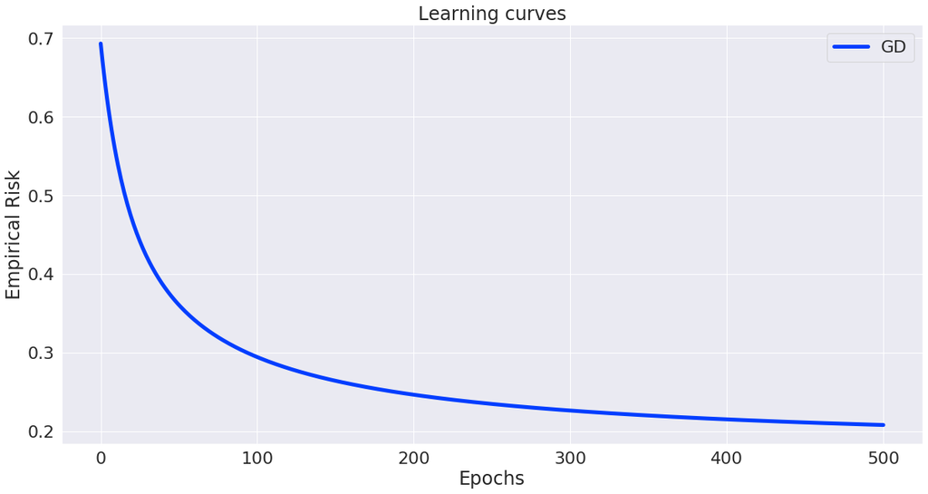

```python
from lib.linear_model import LogisticRegression
from lib.visuals import learning_curve

clf_gd = LogisticRegression(solver='gd', l2=0.01, max_iter=500)
clf_gd.fit(A_train, b_train)

learning_curve(GD=clf_gd)
```

# SGD (Stochastic Gradient Descent)

At iteration k of the SGD algorithm, the following update is executed:

$$ \begin{cases} i \textrm{ chosen randomly in } \{1...n\}\\ x_{k+1} \leftarrow x_{k} - \gamma_k \nabla f_i(x_k) \\ \end{cases} $$

**Question:**

- What stepsize $\gamma_k$ ensures the convergence of this algorithm and under what assumptions?
- Complete **TODO (5)**
- Add your code to **\lib\solvers.py**.

> **Answer**: Since our data $x_k$ is assumed to be stochastic, we can only prove convergence in the statical sense. For example, it can only be proved convergence in the mean. Let $I$ be a random variable from $\{0, 1, 2, ... ,n\}$ uniformly distributed. We randomly choose $I$ and then we calculate $x_I$. We can see that

> $$\mathbb{E}[\nabla f_I (x_k)] = \sum_{i=1}^n P\{I = i\}\nabla f_i(x_k) = \sum_{i = 1}^n \frac{1}{n} \nabla f_i(x_k) = \frac{1}{n}\sum_{i=1}^n \nabla f_i(x_k) = \nabla f(x_k).$$

> This means that the stochastic gradient is an unbiased estimate of the batch gradient. Let us now see the convergence rate of stochastic gradient method. In case when $\nabla f$ is Lipschitz (which is our case) we can use the descent lemma, so we have

> $$f(x_{k+1}) \leq f(x_k) + \nabla f(x_k)^T(x_{k+1} - x_k) + \frac{L}{2}||x_{k+1}- x_k||^2.$$

> Using stochastic gradient iteration $x_{k+1} - x_k = -\gamma_k \nabla f_I (x_k)$ gives

> $$f(x_{k+1}) \leq f(x_k) - \gamma_k \nabla f(x_k)^T \nabla f_I(x_k) + \gamma_k^2 \frac{L}{2}||\nabla f_I(x_k)||^2,$$

> for any choice of $\gamma_k$ and $I$. Let us take the expectatiton with respect to $I$ assuming $P\{I = i\} = \frac{1}{n}$,

> \begin{align*} \mathbb{E}[f(x_{k+1})] &\leq \mathbb{E}\left[f(x_k) - \gamma_k \nabla f(x_k)^T \nabla f_I(x_k) + \gamma_k^2 \frac{L}{2}||\nabla f_I(x_k)||^2 \right]\\ &= f(x_k) - \gamma_k \nabla f(x_k)^T \mathbb{E}[\nabla f_I(x_k)] + \gamma_k^2 \frac{L}{2}\mathbb{E}\left[||\nabla f_I(x_k)||^2 \right]\\ &= f(x_k) - \gamma_k \nabla f(x_k)^T \nabla f(x_k) + \gamma_k^2 \frac{L}{2}\mathbb{E}\left[||\nabla f_I(x_k)||^2 \right]\\ &= f(x_k) - \gamma_k ||\nabla f(x_k)||^2 + \gamma_k^2 \frac{L}{2}\mathbb{E}\left[||\nabla f_I(x_k)||^2 \right]. \end{align*}

> We used linearity of expectation and the fact that $x_k$ and $\gamma_k$ do not depend on $I$. The term with $\gamma_k$ looks like usual measure of progress: big gradient means big progress. But the last term (with $\gamma_k^2$) is the problem: less progress if gradients are very different. Now choosing $\gamma_k = 1/L$ might not be small enough. But we can control this: if $\gamma_k$ is small, then $\gamma_k >> \gamma_k^2$. If we also assume PL then we get

> $$\mathbb{E}[f(x_{k+1})] - f^* \leq (1- 2\gamma_k\mu)(f(x_k) - f^*) + \gamma_k^2 \frac{L}{2}\mathbb{E}\left[||\nabla f_I(x_k)||^2 \right].$$

> The last line looks like linear convergence if we are far from solution and gradients are similar, but no progress if we are close to solution or there is high variance in gradients. Step size $\gamma_k$ controls how fast we move towards solution, and squared step size $\gamma_k^2$ controls how much variance moves us away. Standard assumption is that all $\mathbb{E}\left[||\nabla f_I(x_k)||^2 \right]$ are bounded by constant $B^2$. So, after aplying recursion we have

> $$\mathbb{E}[f(x_{k})] - f^* \leq (1- 2\gamma_k\mu)^k(f(x_0) - f^*) + \frac{\gamma_k^2 L B^2}{2}.$$

> First term looks like linear convergence, but second term does not necessarily go to zero. To get convergence, we need a decreasing step size. We need effect of $B^2$ to go to zero, but we still need to make progress. Classic approach is to choose $\gamma_k$ such that

> $$ \sum_{k=1}^\infty \gamma_k = ∞, \ \ \ \sum_{k=1}^\infty \gamma_k^2 <\infty,$$ which suggests setting $\gamma_k = O(1/k).$ There is a theorem with an explicit $\gamma_k$.

> $\mathbf{Theorem}.$ Let $f$ have an $L$-Lipschitz continuous gradient and let $f$ be $\mu$-strongly convex. If $\mathbb{E}\left[||\nabla f_i(x_k)||^2 \right] \leq B^2$ for all $x_k$ and for some $B$, then SGD algorithm with deacreasing step size $\gamma_k = \frac{2k+1}{2\mu(k+1)^2}$ has a convergence rate of

> $$\mathbb{E}\left[f(x_k) - f^* \right] \leq \frac{LB^2}{2k\mu^2}.$$

> *Proof.* We have already seen that $f$ with given asummptions satisfies

> $$\mathbb{E}[f(x_{k+1}) - f^*] \leq (1- 2\gamma_k\mu)(f(x_k) - f^*) + \frac{\gamma_k^2 L B^2}{2}.$$

> With $\gamma_k = \frac{2k+1}{2\mu(k+1)^2}$ in the previous line, we obtain

> $$\mathbb{E}[f(x_{k+1}) - f^*] \leq \left(\frac{k}{k+1}\right)^{2}(f(x_k) - f^*) + \frac{L B^2(2k+1)^2}{8\mu^2(k+1)^4}.$$

> Multiplying both sides by $(k + 1)^2$ and letting $\delta_f (k) = k^2 \mathbb{E}[f(x_k) − f^*]$, we get

> \begin{align*} \delta_f(k+1) &\leq \delta_f(k) + \frac{LB^2 (2k+1)^2}{8\mu^2 (k+1)^2}\\ &\leq \delta_f(k) + \frac{LB^2}{2\mu^2}, \end{align*}

> where the second line follows from $\frac{2k+1}{k+1} < 2$. Applying recursion on the previous inequality, we have

> $$\delta_{f}(k+1) \leq \delta_f(0) + (k+1)\frac{LB^2}{2\mu^2}.$$

> Having in mind that $\delta_f(0) = 0$, and dividing both sides by $(k+1)^2$, we get

> $$\mathbb{E}\left[f(x_{k+1}) - f^* \right] \leq \frac{LB^2}{2(k+1)\mu^2}.$$ $$\hspace{15cm} \blacksquare$$

```python
def SGD(x0, grad, max_iter, n, L, mu):
    ######## TODO (5) ########
    x         = x0
    x_tab     = np.copy(x)

    for k in range(1, max_iter):
        i = np.random.choice(n)
        stepsize  = (2*k+1)/(2*mu*(k+1)**2)
        x = x - stepsize * grad(x, i)

        if k%n == 0: # each completed epoch
            x_tab = np.vstack((x_tab, x))

    return x, x_tab
```

**Question:** Run the code below to test your code.

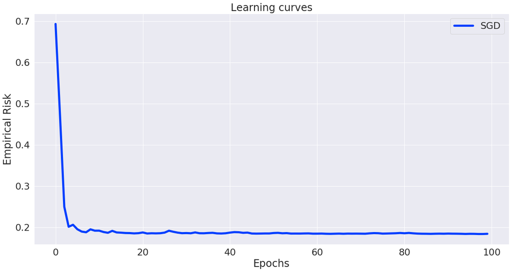

```python
clf_sgd = LogisticRegression(solver='sgd', l2=0.01, max_iter=100*len(b_train))
clf_sgd.fit(A_train, b_train)

learning_curve(SGD=clf_sgd)
```

# SAGA (Stochastic Average Gradient "Amélioré")

SAGA starts by computing a single batch gradient, then at iteration k, the following update is executed:

$$ \begin{cases} i \textrm{ chosen randomly in } \{1...n\}\\ x_{k+1} \leftarrow x_{k} - \gamma_k\big(\nabla f_i(x_k) - \alpha_i + \bar{\alpha}\big) \\ \alpha_i \leftarrow \nabla f_i(x_{k-1}) \end{cases} $$

where $(\alpha_j)_{j=1}^n$ are gradients evaluated at previous iterates and $\bar{\alpha}=\frac{1}{n}\sum^n_{j=1}\alpha_j$.

**Question:**

- What stepsize $\gamma_k$ ensures the convergence of this algorithm and under what assumptions?
- Complete **TODO (6)**
- Add your code to **\lib\solvers.py**.

> **Answer:** This time, we will not prove convergence for the given step size, but we will state the theorem.

> $\mathbf{Theorem}.$ Let $f(x) = \frac{1}{n}\sum_{i=1}^n f_i(x)$. If all $f_i$ have an $L$-Lipschitz continuous gradient and if all $f_i$ are $\mu$-strongly convex. Then SAGA algorithm with step size $\gamma_k = \frac{1}{2(\mu n + L)}$ has a convergence rate of

> $$\mathbb{E}[||x_k - x^*||^2] \leq \left(1 - \frac{\mu}{2(\mu n +L)}\right)^k \left(||x_0 - x^*||^2 + \frac{n}{\mu n + L}\left(f(x_0) - \nabla f(x^*)^T (x_0 - x^*) - f(x^*)\right) \right).$$

> The requirement of strong convexity can be relaxed from needing to hold for each $f_i$ to just holding on $f$, but at the expense of a worse geometric rate $1 − \frac{\mu}{6(\mu n+L)}$, requiring a step size of $\gamma_k = \frac{1}{3(\mu n + L)}$.

```python
def SAGA(x0, grad, max_iter, n, L, mu):
    ######## TODO (6) ########
    x = np.copy(x0)
    stepsize = 1/(3*(mu*n + L))
    alpha_tab = np.zeros((n, x0.size))
    x_tab = np.copy(x)

    for k in range(1, max_iter):
        i = np.random.choice(n)
        g = grad(x, i)
        x = x - stepsize*(g - alpha_tab[i, :] + sum(alpha_tab)/float(n))
        alpha_tab[i, :] = np.copy(g)

        if k%n == 0: # each completed epoch
            x_tab = np.vstack((x_tab, x))

    return x, x_tab
```

**Question:** Run the code below to test your code.

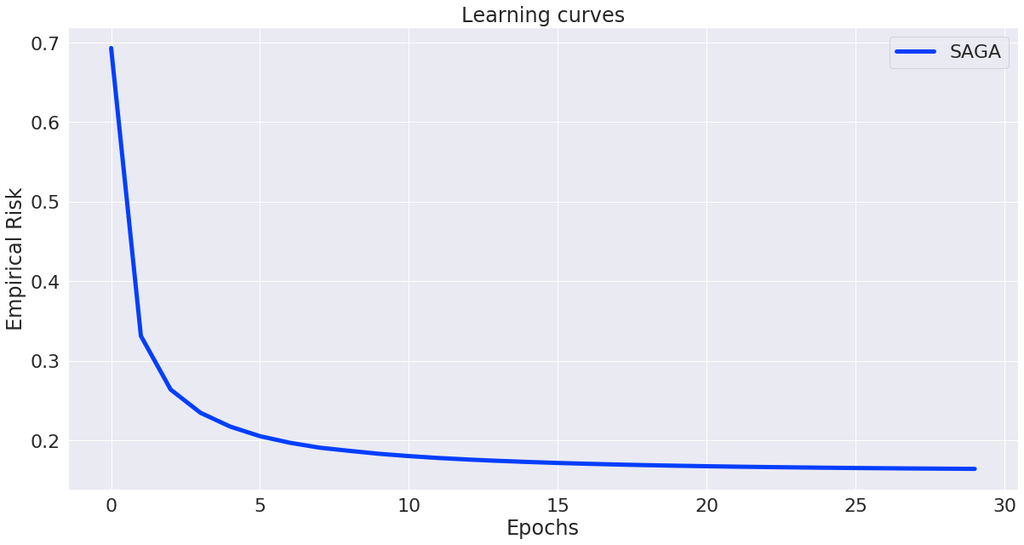

```python
clf_saga = LogisticRegression(solver='saga', l2=0.01, max_iter=30*len(b_train))
clf_saga.fit(A_train, b_train)

learning_curve(SAGA=clf_saga)
```

# SVRG (Stochastic Variance Reduced Gradient)

At iteration k of the SVRG algorithm, we perform the following:

$$ \begin{cases} \textrm{Compute the batch gradient } \nabla f(x_k)\\ \textrm{Initialise }y_0 = x_k\\ \textrm{for m in 0...M-1: } \begin{cases} i \textrm{ chosen randomly in } \{1...n\} \\ y_{m+1} \leftarrow y_{m} - \gamma_k\big(\nabla f_i(y_m) - \nabla f_i(x_k) + \nabla f(x_k)) \end{cases}\\ x_{k+1} \leftarrow y_{M} \end{cases} $$

**Question:**

- What stepsize $\gamma_k$ ensures the convergence of this algorithm and under what assumptions?
- Complete **TODO (7)**
- Add your code to **\lib\solvers.py**.

> **Answer:** Again, we will provide a theorem without a proof here.

> $\mathbf{Theorem}.$ Assume that each $f_i$ is convex, each $\nabla f_i$ is $L$-Lipschitz continuous, and $f$ is $\mu$-strongly convex. Let $x^*$ be the optimal solution, if $M$ and $\gamma_k$ are chosen such that

> $$\rho = \left(1 - 2\gamma_k (1 − \gamma_k L^2)\right)^M + \frac{4\gamma_k L^2}{\mu − \gamma_k L^2} < 1,$$

> then SVRG algorithm converges linearly in expectation as

> $$\mathbb{E}\left[||f(x_k) - f(x^*)||^2\right] < \rho || f(x_0) - f(x^*)||^2.$$

> From what we read, it is suggested to choose $\gamma_k = \frac{0.1}{L}$ and $M = O(n)$, or more specifically, $M = 2n$. But from our experiments, we came to the conclusion that a smaller number of M, such as $M = 30$ and a bigger stepsize, e.g. $\gamma_k = \frac{1}{L}$, we can still get good results in a less costly computation. So we belive it is worth trading speed of convergence with thw complexity of the computatuion.

```python
def SVRG(x0, grad, max_iter, n, L, mu):
    ######## TODO (7) ########
    x = np.copy(x0)
    grad_tab = np.zeros((n, x0.size))
    stepsize = 1/L
    M = 30
    x_tab = np.copy(x)

    for k in range(max_iter):

        batch_grad = grad(x)
        y = np.copy(x)

        for m in range(M):
            i = np.random.choice(n)
            y = y - stepsize*(grad(y, m) - grad(x, m) + batch_grad)

        x = np.copy(y)
        x_tab = np.vstack((x_tab, y))

    return x, x_tab
```

**Question:** Run the code below to test your code.

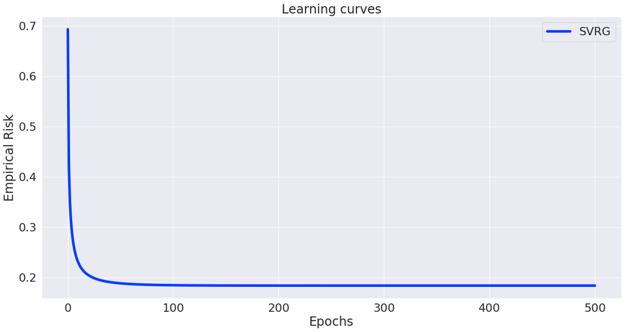

```python
clf_svrg = LogisticRegression(solver='svrg', l2=0.01, max_iter=500)
clf_svrg.fit(A_train, b_train)

learning_curve(SVRG=clf_svrg)
```

# Comparison

**Question:** Run the code below to compare all the methods you've implemented.

```python
epochs = 100
n = len(b_train)

clf_gd   = LogisticRegression(solver='gd', l2=0.01, max_iter=epochs)
clf_sgd  = LogisticRegression(solver='sgd', l2=0.01, max_iter=epochs*n)
clf_saga = LogisticRegression(solver='saga', l2=0.01, max_iter=epochs*n)
clf_svrg = LogisticRegression(solver='svrg', l2=0.01, max_iter=epochs)

clf_gd.fit(A_train, b_train)
clf_sgd.fit(A_train, b_train)
clf_saga.fit(A_train, b_train)
clf_svrg.fit(A_train, b_train)
```

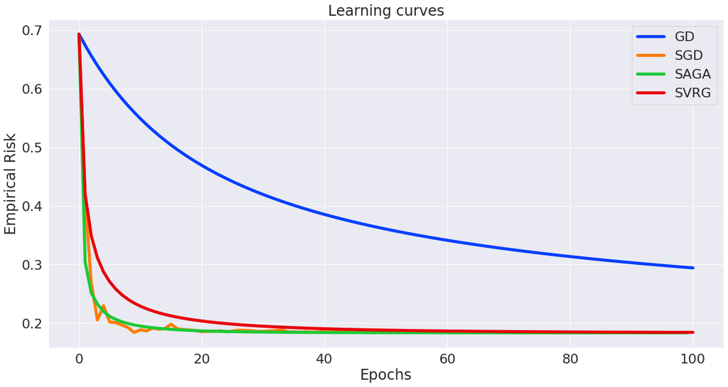

```
gd:	Accuracy on training set: 91.6%
	Accuracy on testing set:  87.9%
sgd:	Accuracy on training set: 94.6%
	Accuracy on testing set:  90.9%
saga:	Accuracy on training set: 95.3%
	Accuracy on testing set:  89.9%
svrg:	Accuracy on training set: 94.9%
	Accuracy on testing set:  89.9%
```

```python
learning_curve(GD=clf_gd, SGD=clf_sgd, SAGA=clf_saga, SVRG=clf_svrg)

for clf, name in zip([clf_gd, clf_sgd, clf_saga, clf_svrg], ['gd', 'sgd', 'saga', 'svrg']):
    print(name + ':' \
          + "\tAccuracy on training set: {0:0.1f}%".format(100*clf.score(A_train, b_train)))
    print("\tAccuracy on testing set:  {0:0.1f}%".format(100*clf.score(A_test, b_test)))
```

# IV. Regularization

**Question:**

- Rewrite the empirical risk minimization objective with both $L_1$ and $L_2$ regularization (with coefficients $l_1$ and $l_2$).
- Is this objective $\mu$-strongly convex, $L$-smooth, differentiable?
- Complete the **TODO (8)** to account for the new term in the objective.
- Add your code to **lib/linear_model.py**.

> **Answer:** Let us rewrite the empirical risk minimization objective with both $L_1$ and $L_2$ regularization. \begin{align*} \min_{x\in\mathbb{R}^d } F(x) := \underbrace{ \frac{1}{m} \sum_{i=1}^m \log( 1+\exp(-b_i \langle a_i,x \rangle) ) + \frac{\ell_2}{2} \|x\|_2^2}_{f(x)} + \underbrace{\ell_1 \|x\|_1 }_{g(x)}. \end{align*} The new function is non-differentiable because of $L_1$ regularization part, so it cannot be smooth also. But $F$ has a smooth part, $f$, and a non-smooth part, $g$, that we can treat with proximal operations. The objective function is still $\mu$-strongly convex, due to $L_2$ regularization part. If we substruct that part from $F$ we will get sum of two convex functions, so $F$ is at least $l_2$-strongly convex.

```
self._empirical_risk = lambda x: sum(self._logistic_loss(A, b, x))/n \
                                 + self.l2/2.0 * np.linalg.norm(x,2) \
                                 ######## TODO (8) ########
                                 + self.l1 * np.linalg.norm(x,1)
```

The minimization algorithms we've implemented have a slow rate of convergence for this new objective function. We will therefore use *proximal* variations of these algorithms.

**Question:** Using the $\textrm{prox}_{l_1 \|\cdot\|_1}$ operator, write down the $k^{th}$ step of proximal GD, proximal SGD, proximal SAGA, and proximal SVRG.

> **Answer:** For minimizing a function $F:\mathbb{R}^d \to \mathbb{R}$ equal to $f+g$ where $f$ is differentiable and the $\mathbf{prox}$ of $g$ is known we apply $\mathbf{prox}$ operator on our update rule to get value of $x$ in iteration $k$. So, we have

> Proximal GD: $$ x_{k+1} \leftarrow \mathbf{prox}_{\gamma l_1 \|\cdot\|_1}\left( x_k - \gamma_k \nabla f_i(x_k) \right) $$

> Proximal SGD: $$ \begin{cases} i \textrm{ chosen randomly in } \{1...n\}\\ x_{k+1} \leftarrow \mathbf{prox}_{\gamma_k l_1 \|\cdot\|_1}\left( x_k - \gamma_k \nabla f_i(x_k) \right) \\ \end{cases} $$

> Proximal SAGA:

> $$ \begin{cases} i \textrm{ chosen randomly in } \{1...n\}\\ x_{k+1} \leftarrow \mathbf{prox}_{\gamma_k l_1 \|\cdot\|_1}\left( x_{k} - \gamma_k\left(\nabla f_i(x_k) - \alpha_i + \bar{\alpha}\right)\right) \\ \alpha_i \leftarrow \nabla f_i(x_k) \\ \end{cases} $$

> where $(\alpha_j)_{j=1}^n$ are gradients evaluated at previous iterates and $\bar{\alpha}=\frac{1}{n}\sum^n_{j=1}\alpha_j$.

> Proximal SVRG:

> $$ \begin{cases} \textrm{Compute the batch gradient } \nabla f(x_k)\\ \textrm{Initialise }y_0 = x_k\\ \textrm{for m in 0...M-1: } \begin{cases} i \textrm{ chosen randomly in } \{1...n\} \\ y_{m+1} \leftarrow \mathbf{prox}_{\gamma_k l_1 \|\cdot\|_1}\left( y_{m} - \gamma_k\big(\nabla f_i(y_m) - \nabla f_i(x_k) + \nabla f(x_k)) \right) \end{cases}\\ x_{k+1} \leftarrow y_{M} \end{cases} $$

**Question:**

- Give a closed-form expression of $\textrm{prox}_{l_1 \|\cdot\|_1}$
- Complete **TODO (9)** (note that you can access the $l_1$ coefficient using **self.l1**).
- Add your code to **\lib\linear_model.py**.

> **Answer:** The optimization problem given by the $\mathbf{prox}$ operator is

> $$\mathbf{prox}_{l_1\|\cdot\|_1}(x) = \arg\min\limits_{u}\left\{\frac{1}{2}||u-x||^2 + l_1 ||u||_1\right\}.$$

> This problem is separable with respect to both $u$ and $x$, hence one could solve the following problem

> $$\arg\min\limits_{u_i}\left\{\frac{1}{2}(u_i-x_i)^2 + l_1 |u_i|\right\}.$$

> Now, one way to proceed is using first order optimality condition and the sub gradient of the $|\cdot|$ function. But the more intuitive way can employ simple trick. The trick is to understand that $u_i$ can be either positive, zero or negative. Assuming $u_i>0$ the derivative is given by $u_i−x_i+l_1$ which vanishes for $u_i =x_i−l_1$ and holds for $x_i>l_1$. The same procedure for the case $u_i < 0$ yields $u_i=x_i+l_1$ for $x_i<−l_1$. For values of $x_i$ in between, since $u_i=0$ and hence the derivative (Sub Gradient) of $u_i$ can freely be chosen on the range $[−l_1,l_1]$ the value of $u_i=0$ holds. Thus, the proximal operator of the $L_1$ norm is:

> $$\textrm{prox}_{l_1 \|\cdot\|_1}(x)= \begin{cases} x_i - l_1 ,& \text{if } x_i\ge l_1 \\ 0,& \text{if } \lvert x_i \rvert \le l_1 \\ x_i + l_1 ,& \text{if } x_i\le -l_1 \end{cases} $$

```python
def prox(x, stepsize):
    ######## TODO (9) ########
    p = np.zeros(n)
    for i in range(n):
        if x[i] < - self.l1*stepsize:
            p[i] = x[i] + self.l1*stepsize
        if x[i] > self.l1*stepsize:
            p[i] = x[i] - self.l1*stepsize
    return p
    pass
```

**Question:**

- Add **prox** to the attributes of the solvers (both in the call to **self.solver** in **/lib/linear_model.py** and in **/lib/solvers.py**) as follows:  
  solver(x0, grad, **prox**, self.max_iter, n, L, mu)
- Add a proximal step to all the algorithms in **/lib/solvers.py**.
- Paste one of these algorithms in the cell bellow.

```python
def SGD(x0, grad, prox, max_iter, n, L, mu):
    ######## TODO (5) ########
    x         = x0
    x_tab     = np.copy(x)

    for k in range(1, max_iter):
        i = np.random.randint(1, n)
        stepsize  = (2*k+1)/(2*mu*(k+1)**2)
        x = prox(x - stepsize * grad(x, i), stepsize)

        if k%n == 0: # each completed epoch
            x_tab = np.vstack((x_tab, x))

    return x, x_tab
```

**Question:** If your proximal gradient descent is correctly implemented, the following cell will plot the support of the solution for various values of $l_1$.

- Interpret the plot and explain what can $L_1$ regularization be used for.

> **Answer:** As we can see from the image below, when increasing the value of $log(l_1)$ we force the coordinates of the values of the solution $x$ which are close to zero to become zero. In other words, $L_1$ regularization favors sparse solutions and therefore restricts attention to a subset of features. These non-null values of $x$ capture a useful feature of the data.

> In our case, the $26^{th}$ and the $27^{th}$ component of the solution hold the most useful information in comparison to the other features. Indeed, they are respectively the first and the second period grade, and their relation to our question (whether a student will pass) is evident.

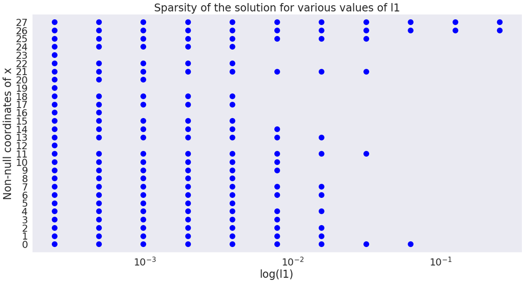

```python
from lib.visuals import l1_regularization_plot

clf = lambda l1: LogisticRegression(solver='gd', l1=l1, l2=0.1, max_iter=1000)

l1_regularization_plot(clf, A_train, b_train)
```

**Question:** The following cell will plot the value of the coordinates of the solution for various values of $l_2$.

- Interpret the plot and explain what can $L_2$ regularization be used for.

> **Answer:** Differently from $L_1$ regularization, the $L_2$ regularization forces the weights to be small but not zero. That means, the bigger the penalization, the smaller the coefficients are. This can be easily seen in the plot below. The value of the coefficients slowly decreases as the vale of $log(l_2)$ increases.

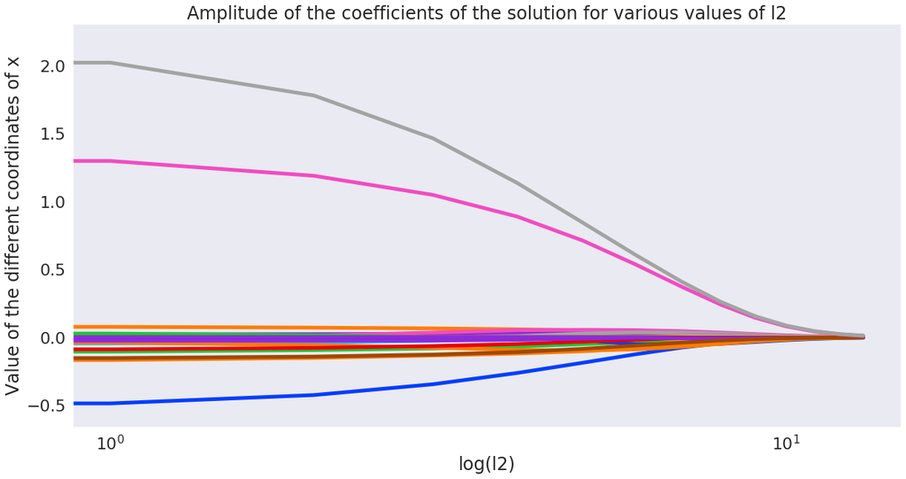

```python
from lib.visuals import l2_regularization_plot

clf = lambda l2: LogisticRegression(solver='gd', l1=0.01, l2=l2, max_iter=1000)

l2_regularization_plot(clf, A_train, b_train)
```

# V. Further development

We expect that you go beyond the lab's questions and that you develop certain aspects of your work, depending on your personal interests and skills, for instance:

- Implementations and numerical tests (further developments, more experiments, etc.)
- Applications in learning or statistics (interpretation of some results, other models, other datasets, etc.)
- Theoretical or mathematical questions (convergence proofs, convergence rates, advanced versions of an algorithm, theoretical analysis of special cases, etc.)

**Keyword ideas**: standard or stochastic Newton method, ADMM, continuation methods, tests on large scale datasets, intuition behind variance reduction, catalyst...

# References

[1] **Mark Schmidt**, Course slides from *CPSC 540 - Machine Learning* (January-April, 2018)

[2] **Hamed Karimi** & **Julie Nutini** & **Mark Schmidt**, Linear Convergence of Gradient and Proximal-Gradient Methods Under the Polyak-Łojasiewicz Condition, *Machine Learning and Knowledge Discovery in Databases: European Conference* (2016)

[3] **Mark Schmidt** & **Nicolas Roux**, Fast Convergence of Stochastic Gradient Descent under a Strong Growth Condition (2016)

[4] **Léon Bottou**, **Frank E. Curtis**, **Jorge Nocedal**, Optimization methods for large-scale machine learning (2018)

[5] **Yan Liu**, **Congying Han**, **Tiande Guo**, A Class of Stochastic Variance Reduced Methods with an Adaptive Stepsize, *University of Chinese Academy of Sciences* (2019)

[6] **Rie Johnson**, **Tong Zhang**, Accelerating Stochastic Gradient Descent using Predictive Variance Reduction, *NIPS'13* (2013)

[7] **Conghui Tan**, **Shiqian Ma**, **Yu-Hong Dai**, **Yuqiu Qian**, Barzilai-Borwein Step Size for Stochastic Gradient Descent, *The Thirtieth Annual Conference on Neural Information Processing Systems (NIPS)* (2016)

[8] **Aaron Defazio**, **Francis Bach**, **Simon Lacoste-Julien**, SAGA: A Fast Incremental Gradient Method With Support for Non-Strongly Convex Composite Objectives, *Advances In Neural Information Processing Systems* (2014)